# PhotoDraw-Exp1-RecognitionAnalysis

Bria Long

8/6/2018

## Load data and do basic preprocessing.

```r
## Read in data outputs from turk data - true/false recognition
r <- read.csv("preprocessed_data/photodraw_recognition_ratings.csv") %>%
  as.tibble()

## redo age for subject who lied about his age -- at Bing so can't be a 6-year-old. Noted in run sheet.
r$age[r$sessionId=="e11533079944053"]=4

## refactor levels to that semantic condition is first, then working memory, then perception
r$condition <- factor(r$condition, levels = c("S", "W", "P"))

d <- read_csv("preprocessed_data/photodraw_data_Aug8.csv") %>%
  select(-X1) %>%
  filter(!is.na(age)) %>%
  mutate(imNameShort = paste0(category, '_sketch', '_', session_id,'_',condition, '_', age,'.png'))
```

#### Convert alphanumeric age to numeric age in python csv

```r
d <- d %>%
  group_by(session_id) %>%
  mutate(age_char = strsplit(age,"e")[[1]][2]) %>%
  mutate(age_num = as.numeric(age_char)) %>%
  select(-age) %>%
  rename(age = age_num)
```

#### Join ratings and python datasets

```r
joined <- left_join(r,d)
```

### Sanity check number of raters per image

```r
ratersPerImage <- r %>%
  distinct(imageName, workerid) %>%
  group_by(imageName) %>%
  summarize(count = n())

assert_that(sum(ratersPerImage$count==30)==(length(unique(r$imageName))))
```

```
## [1] TRUE
```

#### Sanity check number of kids in each condition and age

```r
r %>%
  distinct(sessionId, condition, age) %>%
  group_by(condition) %>%
  summarize(count = n()) %>%
  kable()
```

| condition | count |
| --- | --- |
| S | 20 |
| W | 20 |
| P | 20 |

#### And distribution across age groups and conditions

```r
r %>%
  distinct(sessionId, condition, age) %>%
  group_by(condition,age) %>%
  summarize(count = n())
```

```
## # A tibble: 12 x 3
## # Groups:   condition [?]
##    condition   age count
##    <fct>     <dbl> <int>
##  1 S             4     4
##  2 S             5     8
##  3 S             6     5
##  4 S             7     3
##  5 W             4     5
##  6 W             5     8
##  7 W             6     4
##  8 W             7     3
##  9 P             4     4
## 10 P             5     8
## 11 P             6     5
## 12 P             7     3
```

# Part 2: Descriptive statistics

### Take a look at the raw rating data

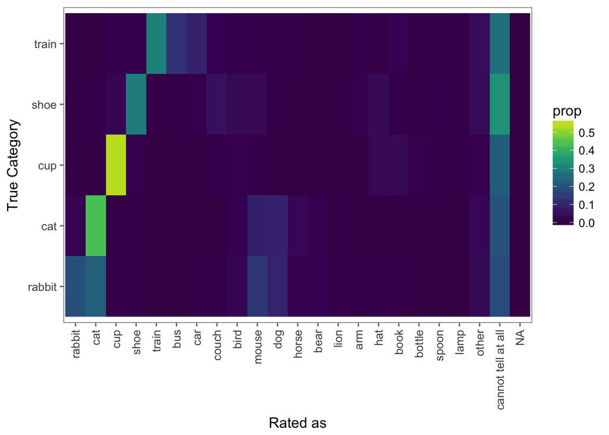

```r
ratingConfusions <- r %>%
  group_by(category, rating)  %>%
  summarize(number = n()) %>%
  group_by(category) %>%
  mutate(prop = number / sum(number)) %>%
  complete(rating, fill = list(prop = 0))

## Reorder so that we have a meaningful confusion matrix
ratingConfusions$category <- factor(ratingConfusions$category, levels = c("rabbit","cat", "cup","shoe","train"))

ratingConfusions$rating <- factor(ratingConfusions$rating, levels = c( "rabbit","cat", "cup","shoe","train","bus","car","couch","bird","mouse","dog","horse","bear","lion","arm",
"hat","book","bottle","spoon","lamp","other","cannot tell at all"))

## Plot it
ggplot(ratingConfusions,
       aes(x = rating, y = category, fill = prop)) +
  geom_tile() +
  ylab("True Category") +
  xlab("Rated as") +
  scale_fill_viridis(limits = c(0, .6),option="viridis") +
  theme(axis.text.x = element_text(angle = 90, hjust = 1, vjust = .5))
```

### Look at num strokes / duration per condition

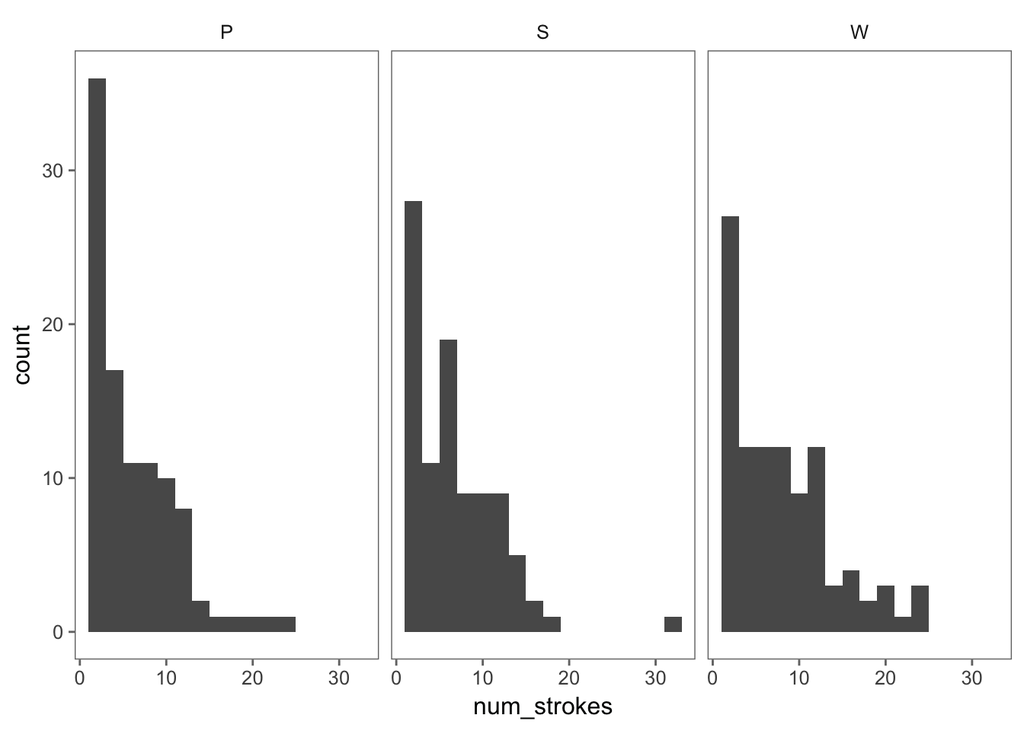

```r
ggplot(d, aes(num_strokes)) +
  geom_histogram(binwidth=2) +
  facet_grid(~condition)
```

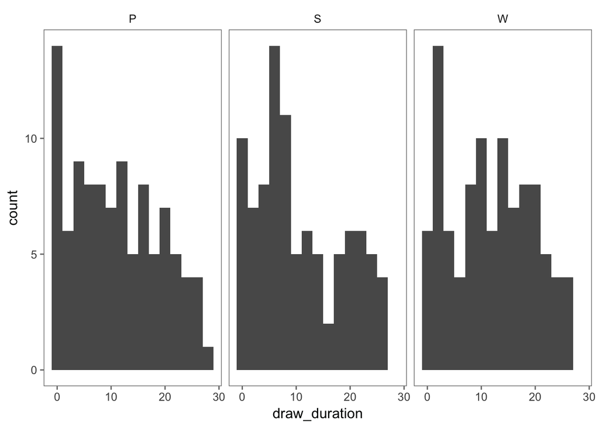

```r
ggplot(d, aes(draw_duration)) +
  geom_histogram(binwidth=2) +
  facet_grid(~condition)
```

## How different are individual participants?

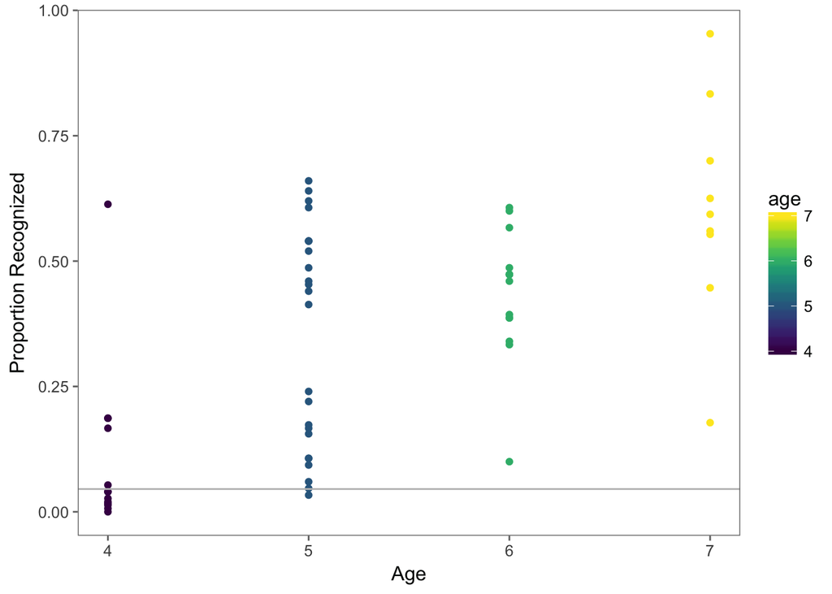

```r
## Get proportion recognized for each image
correctByImage <- r %>%
  group_by(imNameShort) %>% # group by subjects
  mutate(image_correct = mean(correct)) %>%
  distinct(sessionId, category, age, image_correct, condition)

## Get proportion recognized for each participant
indiv <- r %>%
  group_by(sessionId) %>%
  mutate(sub_correct = mean(correct)) %>%
  distinct(sessionId, sub_correct, age) %>% # get unique combos of sessionId and average
  ungroup() %>%
  mutate(sessionId = fct_reorder(sessionId, sub_correct, .desc=TRUE))

## Plot individual children ordered from best to worst
# ggplot(indiv, aes(x = sessionId, y = sub_correct, col = age)) +
#   geom_point() +
#   # theme(axis.text.x = element_text(angle = 90, hjust = 1, vjust = .5)) +
#   theme(axis.text.x = element_blank())+
#   xlab("Individual children") +
#   ylab("Proportion Recognized") +
#   scale_color_viridis() +
#   geom_hline(yintercept=1/22, col='grey') # plot chance line

ggplot(indiv, aes(x = age, y = sub_correct, col = age)) +
  geom_point() +
  # theme(axis.text.x = element_text(angle = 90, hjust = 1, vjust = .5)) +
  xlab("Age") +
  ylab("Proportion Recognized") +
  scale_color_viridis() +
  geom_hline(yintercept=1/22, col='grey') # plot chance line
```

## How does recognizability vary acrosscondition ?

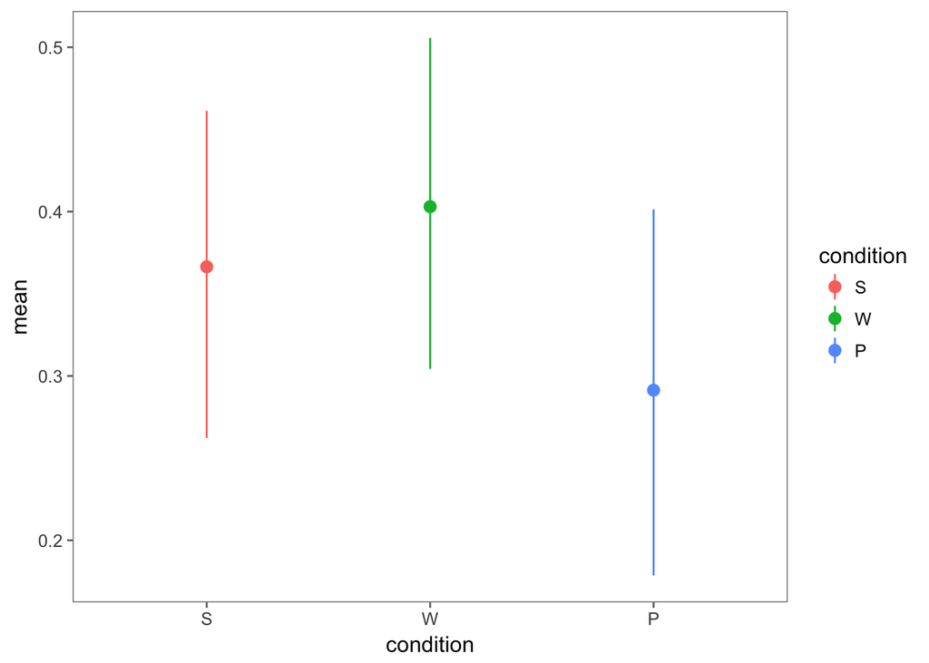

```r
corbyConditionAndSubID <- r %>%
  group_by(sessionId) %>%
  mutate(meanCorrect = mean(correct)) %>%
  distinct(sessionId,meanCorrect,condition) %>% # get rid of duplicates
  group_by(condition) %>%
  multi_boot_standard(col = "meanCorrect")

ggplot(corbyConditionAndSubID, aes(x = condition, y = mean, col=condition)) +
  geom_pointrange(aes(ymin = ci_lower, ymax = ci_upper))
```

### Look at individual children’s performance in these conditions by their age

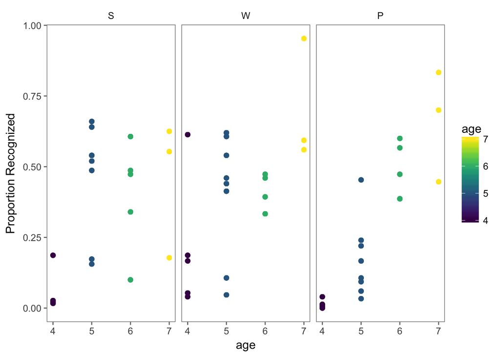

```r
corbyChild <- r %>%
  group_by(condition,sessionId, age) %>%
  mutate(avgCorrect = mean(correct))

ggplot(corbyChild, aes(x = age, y = avgCorrect, col=age)) +
  geom_jitter(width = .01, alpha = .5)  +
  facet_grid(~condition) +
  scale_color_viridis() +
  ylab("Proportion Recognized")
```

## How does recognizability vary across age and condition, collapsing across items?

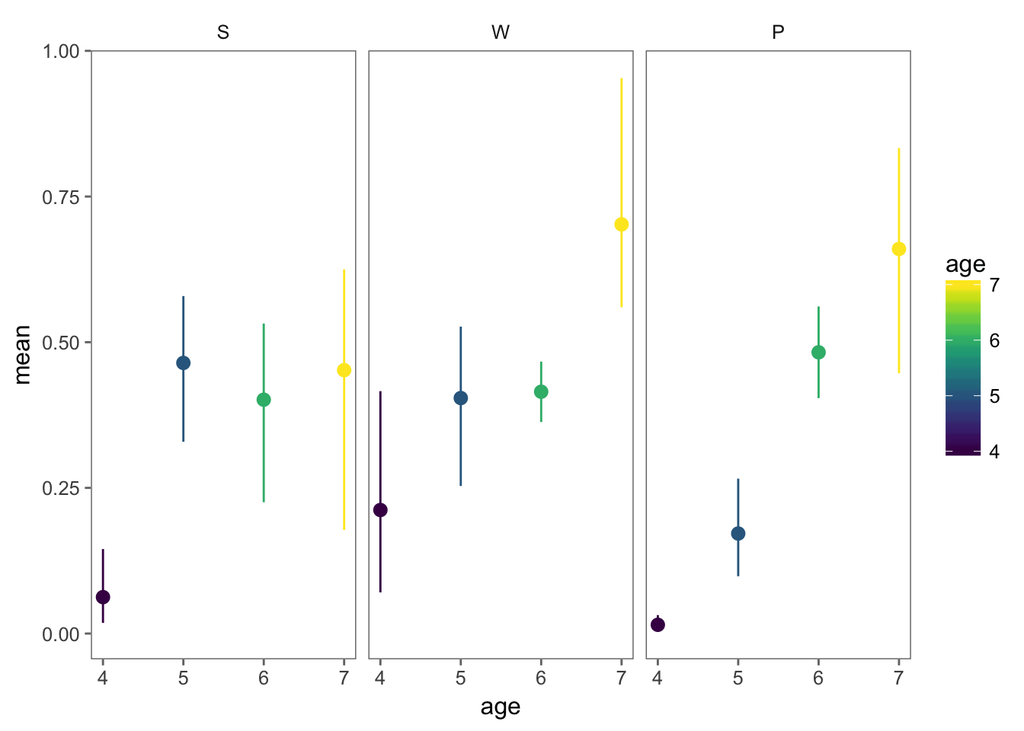

```r
## Get the percent recognized for each age group / condition
corbyCondition <- r %>%
  group_by(sessionId, age, condition) %>% # group by subjects
  summarise(meanCorrect=mean(correct)) %>% # calculate mean correct (subject-level average correct)
  group_by(condition,age) %>% ## critical step: group by BOTH condition and age to get CIs for each combination of age (4,5,6,7) and condition (S,W,P)
  multi_boot_standard(col = "meanCorrect")

ggplot(corbyCondition, aes(x = age, y = mean, col=age)) +
  scale_color_viridis()  +
  geom_pointrange(aes(ymin = ci_lower, ymax = ci_upper)) +
  facet_grid(~condition)
```

## At the image level,how do num strokes / draw duration / avg_stroke_legth relate to recognizability?

```r
corByItem <- joined %>%
  group_by(imNameShort) %>%
  mutate(avgCorrect = mean(correct)) %>% # IMAGE level correctness
  distinct(imNameShort, avgCorrect, draw_duration, num_strokes, avg_stroke_length,age, condition)
```

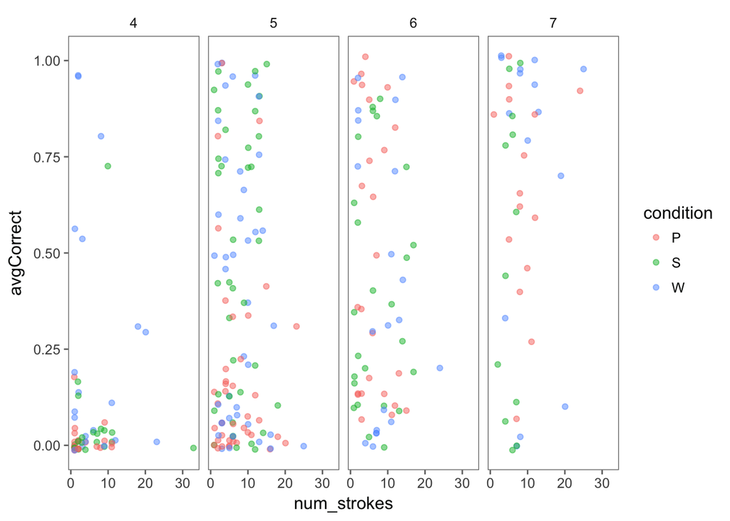

```r
ggplot(corByItem, aes(x = num_strokes, y = avgCorrect, col=condition)) +
    geom_jitter(width = .1, alpha = .5) +
    facet_grid(~age)
```

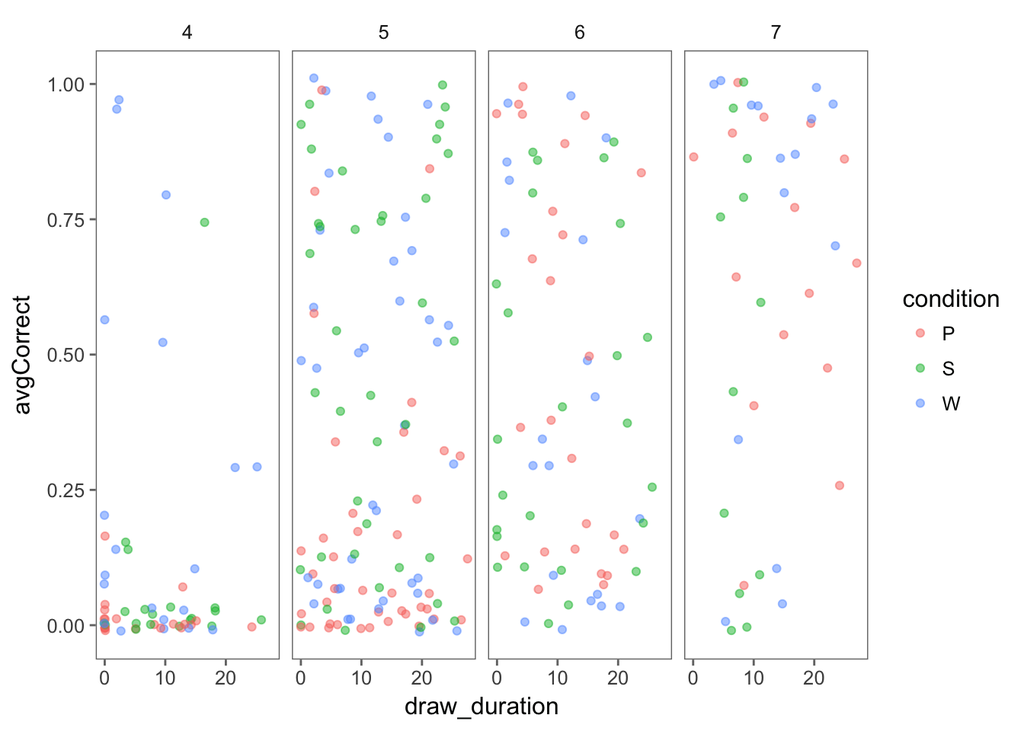

```r
ggplot(corByItem, aes(x = draw_duration, y = avgCorrect, col=condition)) +
    geom_jitter(width = .1, alpha = .5) +
    facet_grid(~age)
```

## How does this trend break down by the catergory that children drew?

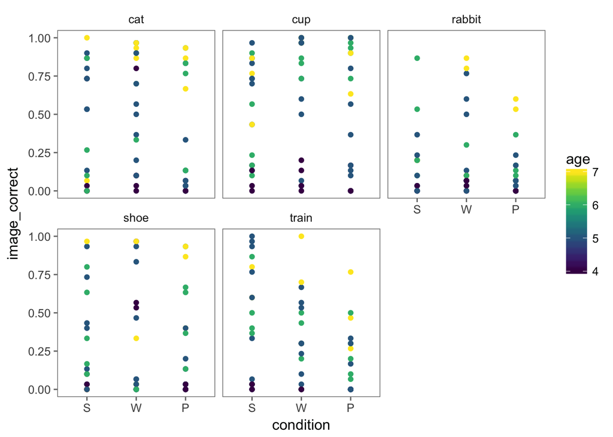

```r
ggplot(correctByImage, aes(x = condition, y = image_correct, col=age)) +
  geom_point() +
  facet_wrap(~category) +
  scale_color_viridis()
```

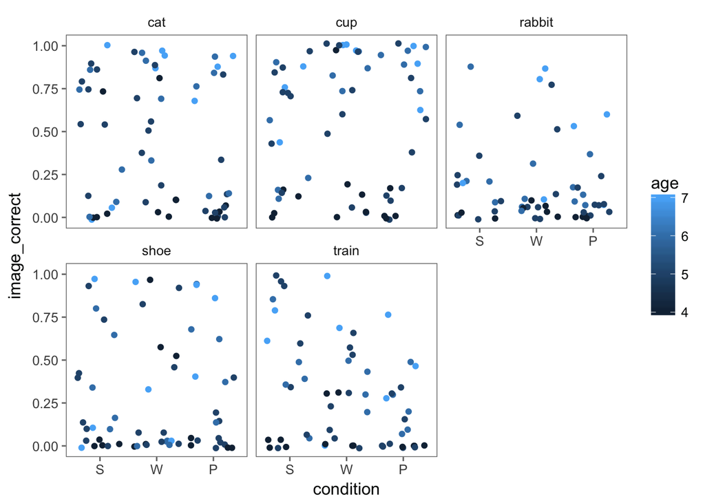

```r
ggplot(correctByImage, aes(x = condition, y = image_correct, col=age)) +
  geom_jitter() +
  facet_wrap(~category)
```

# Part 3: Inferential Statistics

```r
corbySketch <- r %>%
  group_by(imNameShort) %>%
  mutate(propCorrect=mean(correct)) %>%
  distinct(imNameShort, condition, age, category, propCorrect, sessionId)

# scale age
corbySketch$age_sc = scale(corbySketch$age, scale = FALSE) # center but don't scale age

## Adding random slopes on participants causes the model to fail to converge, only keeping random intercepts.
model_lmer <- lmer(propCorrect ~ age_sc*condition + (1 | sessionId) + (condition | category),  data = corbySketch)

model_summary = summary(model_lmer)$coef
```

### Check residuals of the model

Seem relatively evenly distributed around zero; suggests lmer isn’t too bad of a fit.

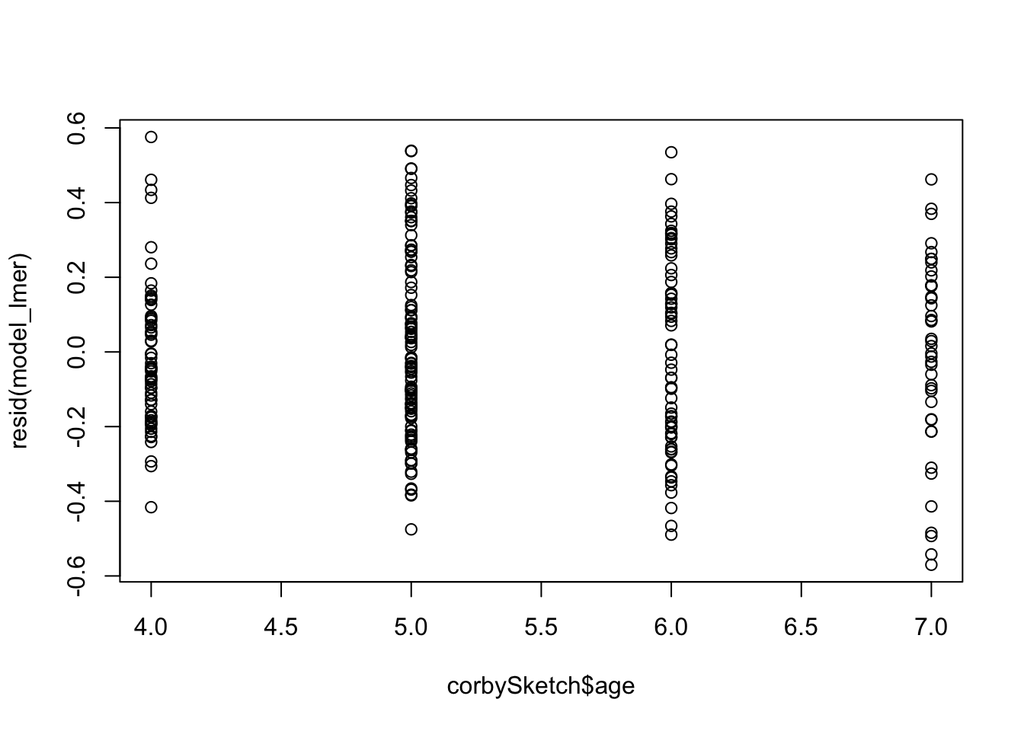

```r
plot(corbySketch$age,resid(model_lmer))
```

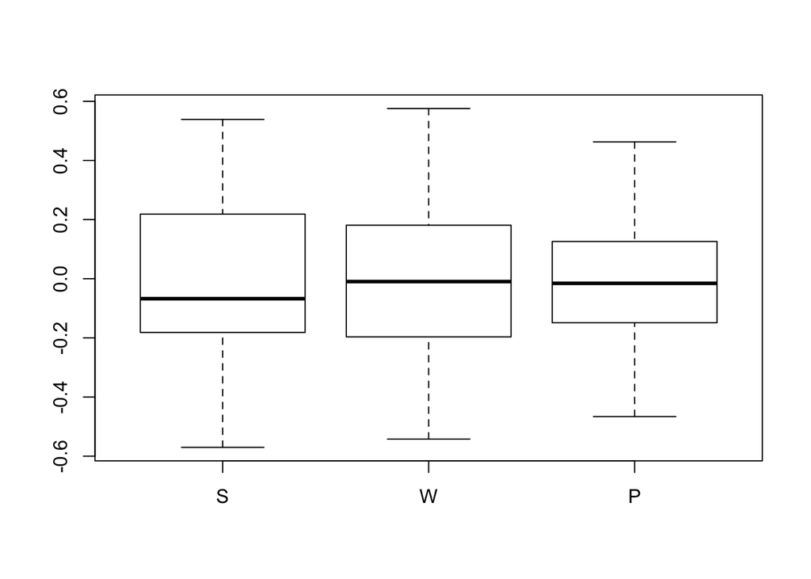

```r
plot(corbySketch$condition,resid(model_lmer))
```

### Get out some model predictions and plot them on top of both the raw data for each sketch and at the participant-averaged level

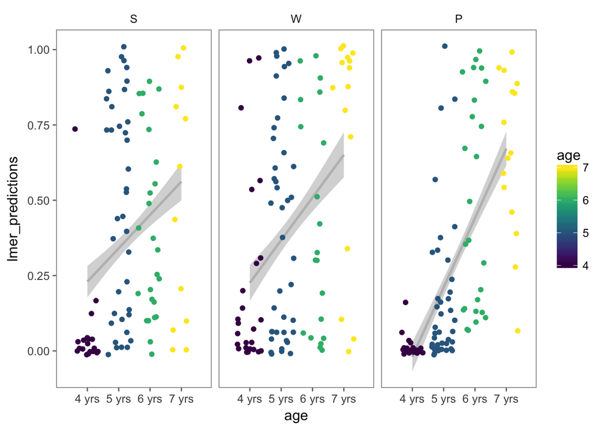

```r
predicted_df = data.frame(lmer_predictions = predict(model_lmer, corbySketch), age=corbySketch$age, condition=corbySketch$condition)

## Model prediction lines overlaid on raw data fed to the model
ggplot(data = predicted_df, aes(x=age, y=lmer_predictions)) +
  facet_grid(~condition) +
  scale_color_viridis()  +
  stat_smooth(method="lm", col='grey') + # plot smoothed line over predictions
  scale_x_discrete(limits=c(4,5,6,7),labels=c("4 yrs", "5 yrs", "6 yrs", "7 yrs")) +
  geom_jitter(data = corbySketch, aes(x=age, y=propCorrect, col=age)) # now plot raw corbysketch data
```

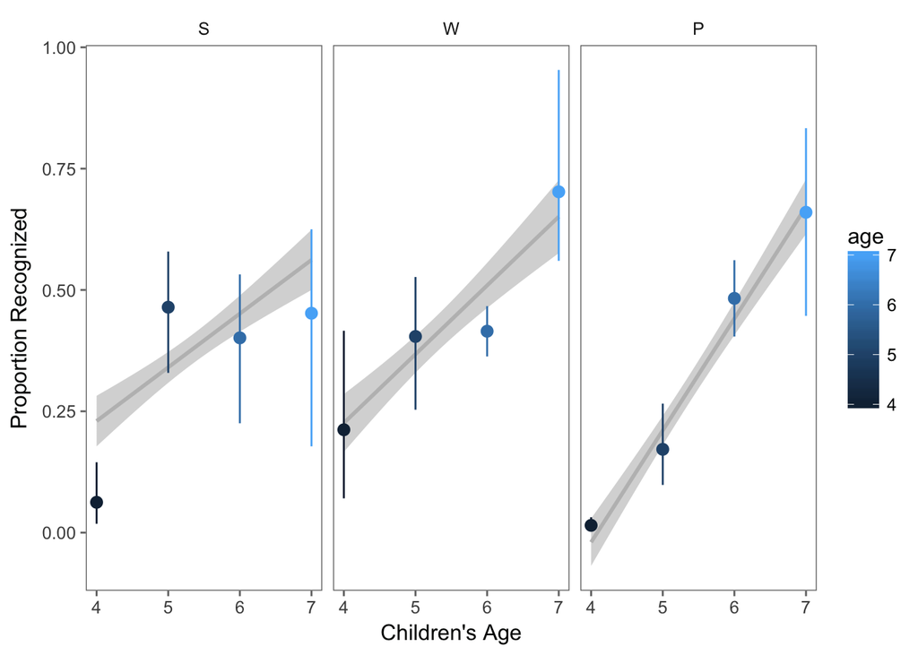

```r
## Model prediction lines overlaid on subject-level CI data
ggplot(data = predicted_df, aes(x=age, y=lmer_predictions)) +
  facet_grid(~condition) +
  stat_smooth(method="lm", col='grey') + # plot smoothed line
  geom_pointrange(data = corbyCondition,aes(x = age, y = mean, col=age, ymin = ci_lower, ymax = ci_upper)) +
  xlab("Children's Age") +
  ylab("Proportion Recognized")
```

## Exploratory analysis: We have a somewhat uneven distribution of kids across ages (though even across condition). Do these results hold when we bin by “younger” and “older” kids to get a more even split?

### Plot how accuracy differs by these age group and condition

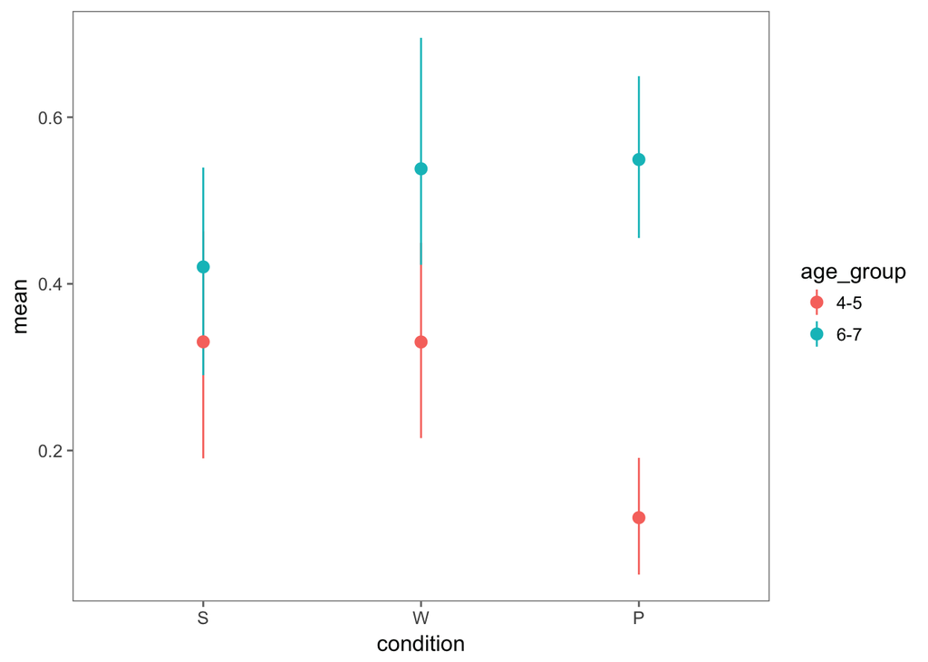

```r
r <- r %>%
  mutate(age_group = cut(age, c(3.9, 5, 8), labels = c("4-5","6-7")))

corbyAgeGroup <- r %>%
  group_by(sessionId)%>%
  mutate(meanCorrect = mean (correct)) %>%
  distinct(sessionId, age_group, condition, meanCorrect)%>%
  group_by(condition, age_group) %>%
  multi_boot_standard(col="meanCorrect")

ggplot(corbyAgeGroup, aes(x = condition, y = mean, col=age_group)) +
  geom_pointrange(aes(ymin = ci_lower, ymax = ci_upper))
```

### Run inferential model statistics for age group

```r
corbySketch <- corbySketch %>%
  mutate(age_group = cut(age, c(3.9, 5, 8), labels = c("4-5","6-7")))

model_lmer <- lmer(propCorrect ~ age_group*condition + (1 | sessionId) + (condition | category),  data = corbySketch)
summary(model_lmer)
```

```
## Linear mixed model fit by REML t-tests use Satterthwaite approximations
##   to degrees of freedom [lmerMod]
## Formula:
## propCorrect ~ age_group * condition + (1 | sessionId) + (condition |
##     category)
##    Data: corbySketch
##
## REML criterion at convergence: 130.8
##
## Scaled residuals:
##     Min      1Q  Median      3Q     Max
## -2.0783 -0.6624 -0.0778  0.6172  2.1142
##
## Random effects:
##  Groups    Name        Variance Std.Dev. Corr
##  sessionId (Intercept) 0.028884 0.16995
##  category  (Intercept) 0.012629 0.11238
##            conditionW  0.006176 0.07859  0.53
##            conditionP  0.006107 0.07815  0.09 0.89
##  Residual              0.065349 0.25563
## Number of obs: 294, groups:  sessionId, 60; category, 5
##
## Fixed effects:
##                           Estimate Std. Error         df t value Pr(>|t|)
## (Intercept)              0.3306495  0.0780845 12.6807362   4.235  0.00103
## age_group6-7             0.0842012  0.0947708 55.3297441   0.888  0.37813
## conditionW              -0.0003931  0.0896315 28.9260469  -0.004  0.99653
## conditionP              -0.2112050  0.0910432 27.0033184  -2.320  0.02815
## age_group6-7:conditionW  0.1236376  0.1349149 53.9996348   0.916  0.36353
## age_group6-7:conditionP  0.3455210  0.1331233 54.0341741   2.595  0.01214
##
## (Intercept)             **
## age_group6-7
## conditionW
## conditionP              *
## age_group6-7:conditionW
## age_group6-7:conditionP *
## ---
## Signif. codes:  0 '***' 0.001 '**' 0.01 '*' 0.05 '.' 0.1 ' ' 1
##
## Correlation of Fixed Effects:
##             (Intr) ag_6-7 cndtnW cndtnP a_6-7:W
## age_grop6-7 -0.482
## conditionW  -0.377  0.420
## conditionP  -0.480  0.414  0.572
## ag_grp6-7:W  0.339 -0.702 -0.562 -0.291
## ag_grp6-7:P  0.343 -0.712 -0.299 -0.583  0.500
```

Looks like we still see an interaction between age_group and condition, though the main effect of 4-5 year-olds and 6-7 year-olds is no longer significant on it’s own.

SRCD Abstract:

The role of memory in children’s drawings of object categories Bria Long, Judy Fan, Yi Feng, Renata Chai, & Michael C. Frank

Consistent with prior work (Long, Fan, & Frank, 2018), we found a strong effect of age; older children produced overall more recognizable drawings (b = 0.362, SE =0.064, z = 5.632, p =0.001). Contrary to our expectations, we found that overall children did not draw more recognizable drawings in the perception or working memory conditions than the semantic condition (perception condition M =0.291% recognized, semantic condition, M=0.366%, working memory condition, M=0.403%). However, we found an interaction between age and the perception condition (b=0.127, SE=0.061, z= 2.095, p=0.041): younger children drew less recognizable drawings in the perception condition, while the recognizability of older children’s drawings slightly increased.